# HW 3 Solutions

## Question 1 (2 pts)

The null hypothesis is $H_0: \beta_1 = 0$, and the alternative hypothesis is $H_A: \beta_1 \neq 0$.

**Grading:** 1 pt for null, 1 pt for alternative. Lose 1 pt if not written in terms of $\beta_1$.

## Question 2 (4 pts)

Full model:

$Survived_i \sim Bernoulli(\pi_i)$

$\log \left( \dfrac{\pi_i}{1 - \pi_i} \right) = \beta_0 + \beta_1 Age_i$

Reduced model:

$Survived_i \sim Bernoulli(\pi_i)$

$\log \left( \dfrac{\pi_i}{1 - \pi_i} \right) = \beta_0$

**Grading:** 2 pts for full model, 2 pts for reduced model. Lose 1 pt for incorrect notation (missing subscripts, adding hats, etc.) Lose 1 pt if only the systematic component is included (missing random component).

## Question 3

### (a) (3 pts)

```r
m2 <- glm(Survived ~ 1, data = titanic, family = binomial)
summary(m2)
```

```
##
## Call:
## glm(formula = Survived ~ 1, family = binomial, data = titanic)
##
## Deviance Residuals:
##    Min      1Q  Median      3Q     Max
## -1.021  -1.021  -1.021   1.342   1.342
##
## Coefficients:
##             Estimate Std. Error z value Pr(>|z|)
## (Intercept)  -0.3799     0.0762  -4.985  6.2e-07 ***
## ---
## Signif. codes:  0 '***' 0.001 '**' 0.01 '*' 0.05 '.' 0.1 ' ' 1
##
## (Dispersion parameter for binomial family taken to be 1)
##
##     Null deviance: 964.52  on 713  degrees of freedom
## Residual deviance: 964.52  on 713  degrees of freedom
## AIC: 966.52
##
## Number of Fisher Scoring iterations: 4
```

$Survived_i \sim Bernoulli(\pi_i)$

$\log \left( \dfrac{\widehat{\pi}_i}{1 - \widehat{\pi}_i} \right) = -0.38$

**Grading:** Lose 1 pt if missing code, lose 2 pts if missing equation of the fitted reduced model. Lose 1 pt for incorrect notation (missing subscripts, hats, etc.)

### (b) (1 pt)

The deviance of the reduced model is 964.52

**Grading:** it is ok if they round slightly. If they didn’t remove missing values before fitting the model, they would get 1186.7 instead. If they don’t remove missing values, lose 1 pt.

### (c) (3 pts)

```r
m1 <- glm(Survived ~ Age, data = titanic, family = binomial)
summary(m1)
```

```
##
## Call:
## glm(formula = Survived ~ Age, family = binomial, data = titanic)
##
## Deviance Residuals:
##     Min       1Q   Median       3Q      Max
## -1.1488  -1.0361  -0.9544   1.3159   1.5908
##
## Coefficients:
##             Estimate Std. Error z value Pr(>|z|)
## (Intercept) -0.05672    0.17358  -0.327   0.7438
## Age         -0.01096    0.00533  -2.057   0.0397 *
## ---
## Signif. codes:  0 '***' 0.001 '**' 0.01 '*' 0.05 '.' 0.1 ' ' 1
##
## (Dispersion parameter for binomial family taken to be 1)
##
##     Null deviance: 964.52  on 713  degrees of freedom
## Residual deviance: 960.23  on 712  degrees of freedom
## AIC: 964.23
##
## Number of Fisher Scoring iterations: 4
```

$Survived_i \sim Bernoulli(\pi_i)$

$\log \left( \dfrac{\widehat{\pi}_i}{1 - \widehat{\pi}_i} \right) = -0.057 - 0.011 Age_i$

**Grading:** Lose 1 pt if missing code, lose 2 pts if missing equation of the fitted full model. Lose 1 pt for incorrect notation (missing subscripts, hats, etc.)

### (d) (1 pt)

The deviance of the full model is 960.23

## Question 4 (2 pts)

In this case, the reduced model *is* the intercept-only model. Therefore, the deviance of the reduced model agrees with the null deviance.

## Question 5 (1 pt)

$G = 964.52 - 960.23 = 4.29$

**Grading:** it is ok if they round slightly

## Question 6

### (a) (3 pts)

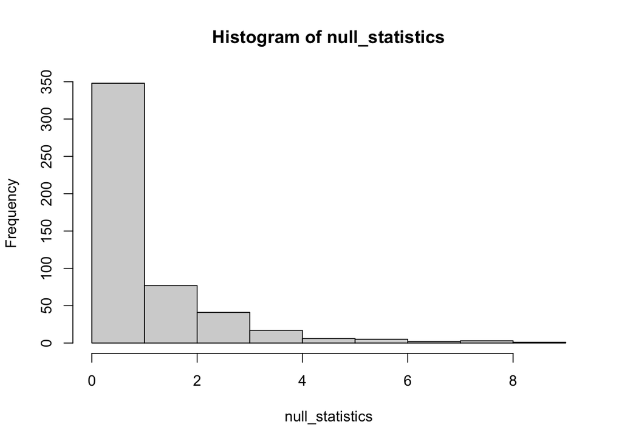

```r
nsim <- 500
null_statistics <- rep(0, nsim)
for(i in 1:nsim){
  x <- titanic$Age
  p <- exp(-0.38 + 0*x)/(1 + exp(-0.38 + 0*x))
  y <- rbinom(length(x), 1, p)
  m1 <- glm(y ~ x, family = binomial)

  null_statistics[i] <- m1$null.deviance -
    m1$deviance
}
hist(null_statistics)
```

**Grading:** Lose 1 pt for not changing the explanatory variable `x` (should be Age), lose 1 pt for not changing the intercept in the probabilities (should be -0.38).

### (b) (2 pts)

The observed test statistic was $G = 4.29$, which looks reasonably unusual compared to our null statistics. Most simulated statistics from the null distribution are below 4 or so.

**Grading:** 1 pt for correct answer, 1 pt for explaining reasoning

### (c) (2 pts)

```r
mean(null_statistics >= 4.29)
```

```
## [1] 0.028
```

**Grading:** 1 pt for showing code, 1 pt for correctly using observed drop in deviance

## Question 7 (2 pts)

```r
x <- seq(0, 1, 0.1)
x_cubed <- rep(0, length(x))
for(i in 1:length(x)){
  x_cubed[i] <- x[i]^3
}
x_cubed
```

```
##  [1] 0.000 0.001 0.008 0.027 0.064 0.125 0.216 0.343 0.512 0.729 1.000
```

**Grading:** 2 pts for using `x[i]^3`. They don’t need to rename the vector `x_cubed`, but it would be helpful.

## Question 8 (2 pts)

```r
x <- seq(0, 2, 0.05)
x_cubed <- rep(0, length(x))
for(i in 1:length(x)){
  x_cubed[i] <- x[i]^3
}
x_cubed
```

```
##  [1] 0.000000 0.000125 0.001000 0.003375 0.008000 0.015625 0.027000 0.042875
##  [9] 0.064000 0.091125 0.125000 0.166375 0.216000 0.274625 0.343000 0.421875
## [17] 0.512000 0.614125 0.729000 0.857375 1.000000 1.157625 1.331000 1.520875
## [25] 1.728000 1.953125 2.197000 2.460375 2.744000 3.048625 3.375000 3.723875
## [33] 4.096000 4.492125 4.913000 5.359375 5.832000 6.331625 6.859000 7.414875
## [41] 8.000000
```

**Grading:** They need to change both the range of `x` (0 to 2), and the increment (by 0.05). It is fine for them to calculate either $x^2$ or $x^3$

## Question 9

### (a) (2 pts)

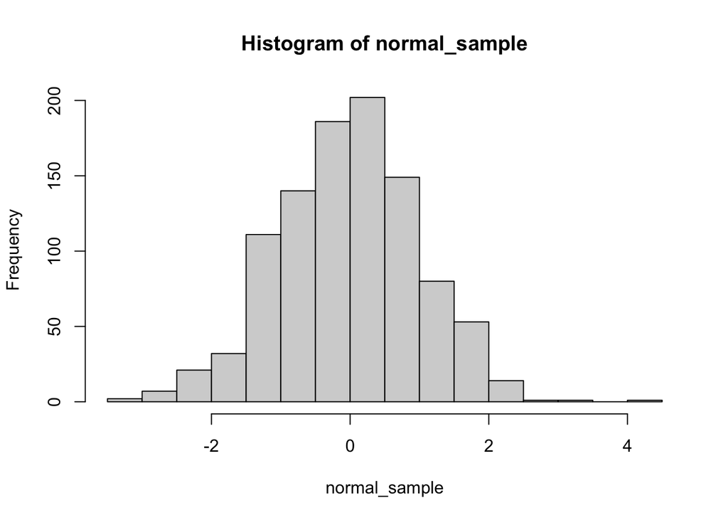

```r
n <- 1000
normal_sample <- rep(0, n)
for(i in 1:n){
  normal_sample[i] <- rnorm(1, 0, 1)
}
hist(normal_sample)
```

### (b) (1 pt)

Yes, the histogram looks like a normal distribution (unimodal, symmetric, bell-shaped, etc.)

**Grading:** 1 pt for correct answer.

## Question 10

### (a) (2 pts)

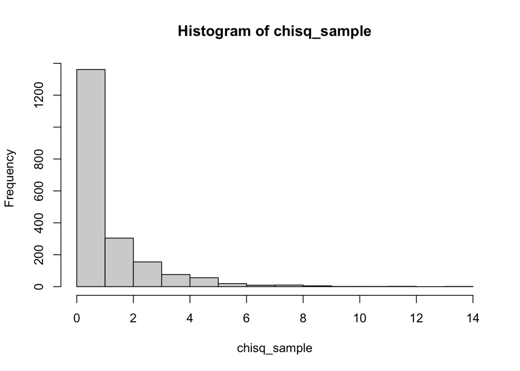

```r
n <- 2000
chisq_sample <- rep(0, n)
for(i in 1:n){
  chisq_sample[i] <- rchisq(1, df=1)
}
hist(chisq_sample)
```

**Grading:** They need to change both `n` and the distribution they are sampling from. They don’t need to change the name of the vector, but it would be helpful.

### (b) (1 pt)

It looks pretty similar!

**Grading:** 1 pt for correct answer

## Question 11 (Extra credit)

They can earn 1 pt of extra credit for each part of this question which they answer correctly.

### (a) (1 pt)

The issue is that `pi0` has length 11, but `likelihood` has length 12. When we go to access `pi0[12]`, there is nothing there!

### (b) (1 pt)

```r
pi0 <- seq(0, 1, 0.1)
likelihood <- rep(0, 12)
for(i in 1:11){
  likelihood[i] <- pi0[i]^2 * (1 - pi0[i])^3
}
likelihood
```

```
##  [1] 0.00000 0.00729 0.02048 0.03087 0.03456 0.03125 0.02304 0.01323 0.00512
## [10] 0.00081 0.00000 0.00000
```